# Project 1: What do markets like to hear?

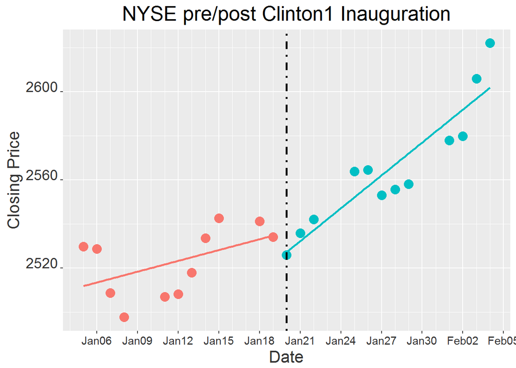

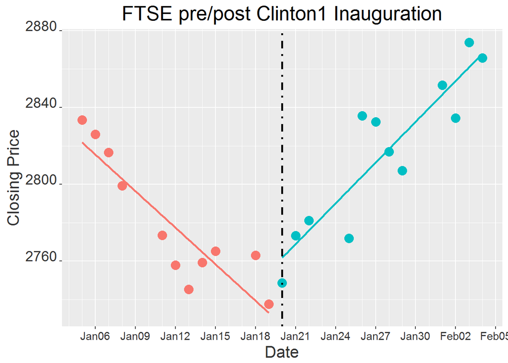

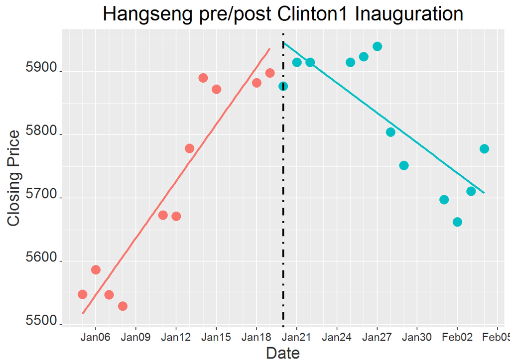

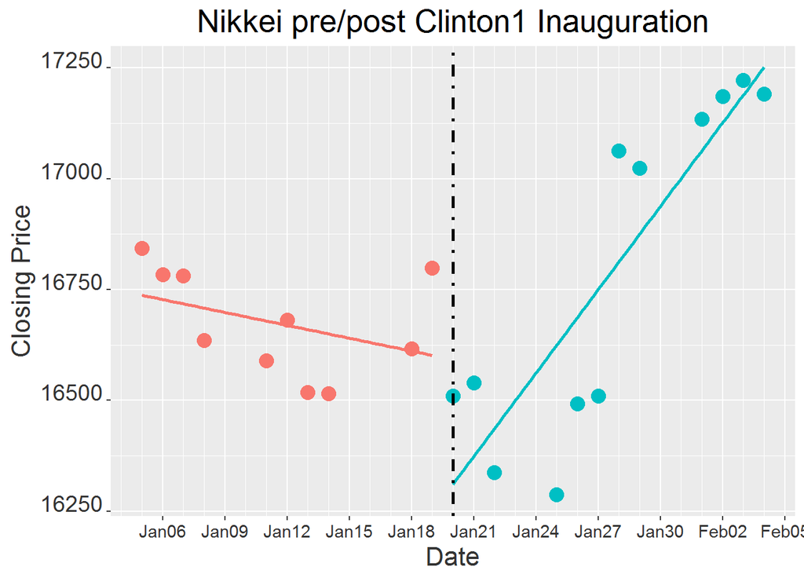

| President | id | Index | GradChange |
| --- | --- | --- | --- |
| WilliamJClinton-1 | 1 | Dow Jones | 552.90% |
|  | 2 | S&P500 | 172.92% |
|  | 3 | Nasdaq | -75.01% |
|  | 4 | NYSE | 204.08% |
|  | 5 | FTSE | 211.67% |
|  | 6 | Hang Seng | -152.82% |
|  | 7 | Nikkei | 746.92% |

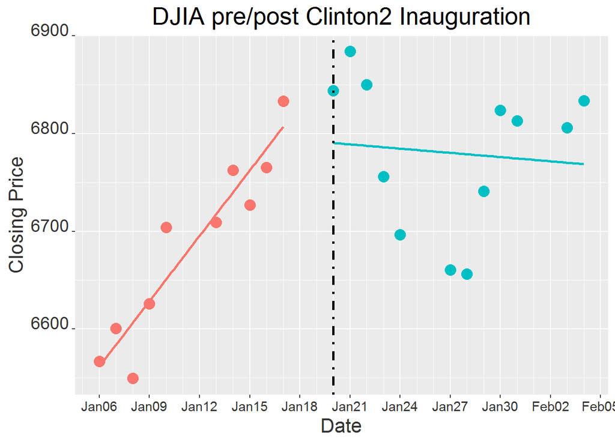

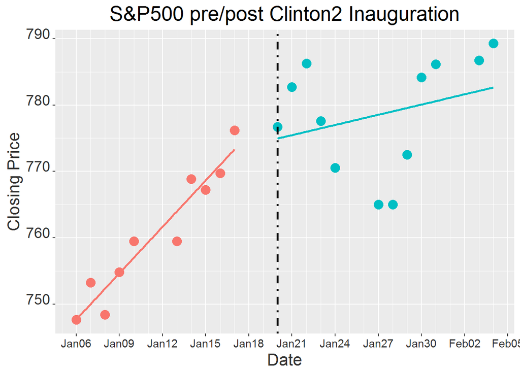

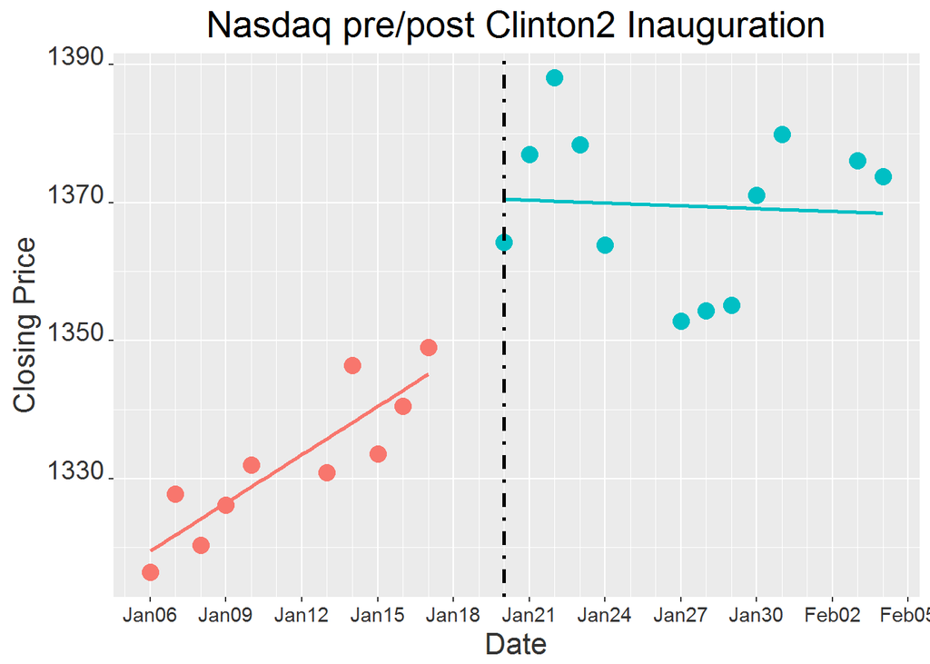

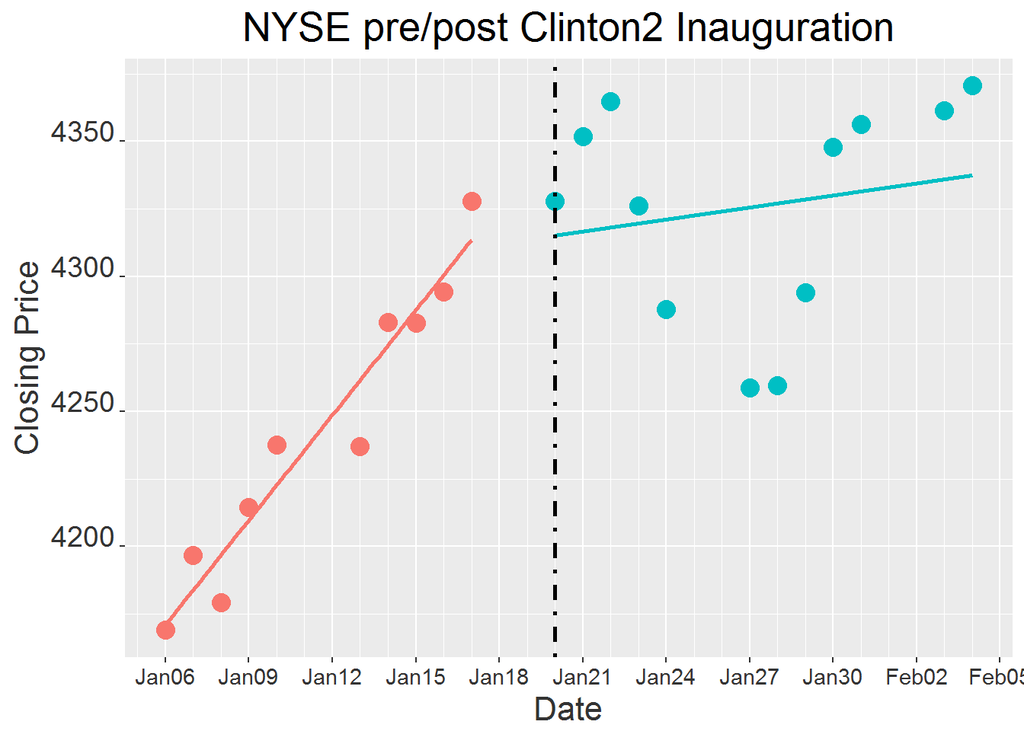

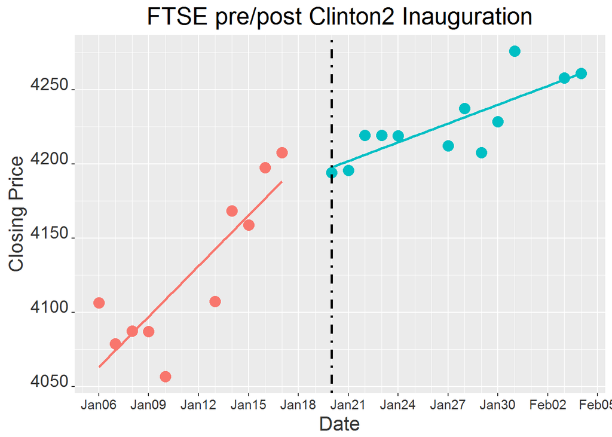

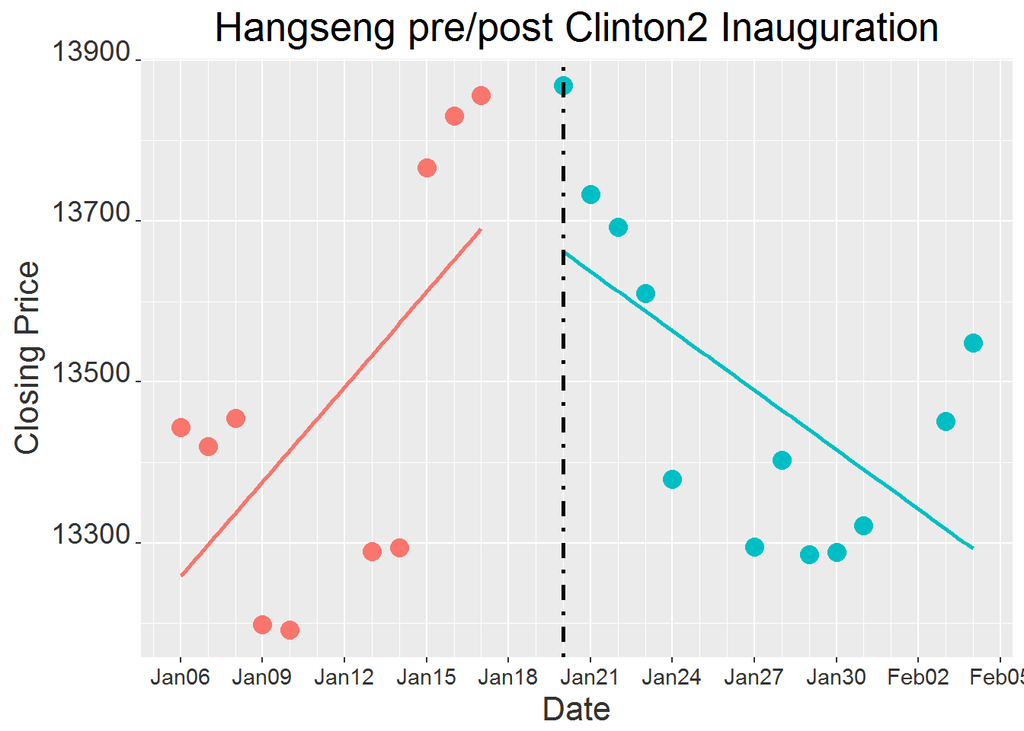

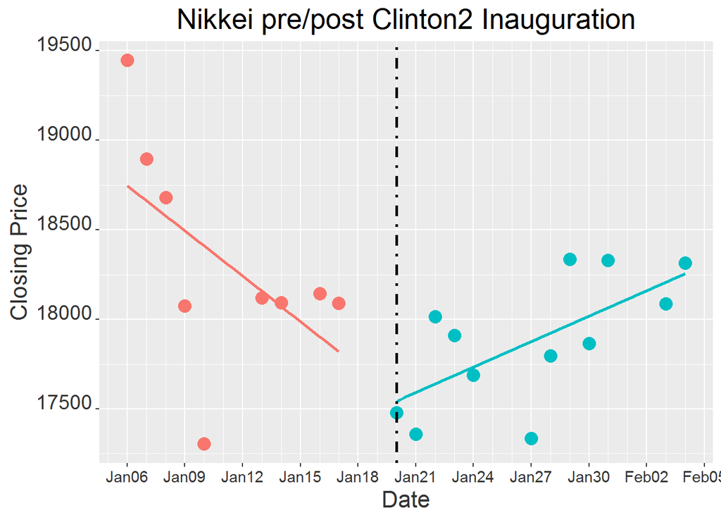

| President | id | Index | GradChange |
| --- | --- | --- | --- |
| WilliamJClinton-2 | 1 | Dow Jones | -106.47% |
|  | 2 | S&P500 | -78.05% |
|  | 3 | Nasdaq | -105.80% |
|  | 4 | NYSE | -88.57% |
|  | 5 | FTSE | -62.87% |
|  | 6 | Hang Seng | -162.75% |
|  | 7 | Nikkei | 156.48% |

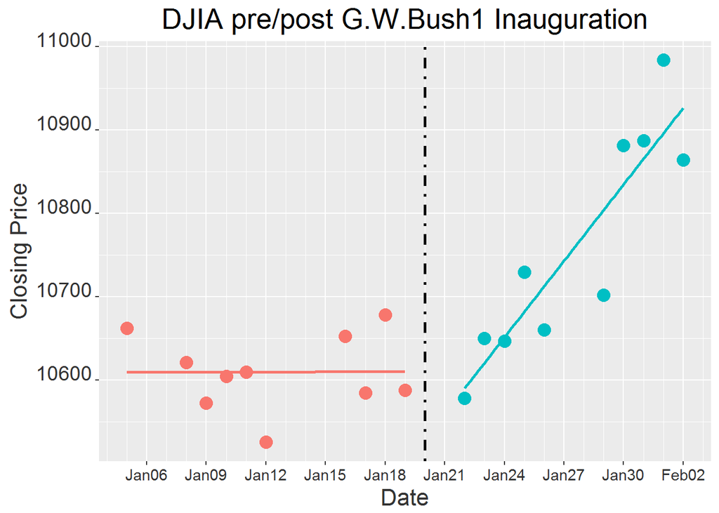

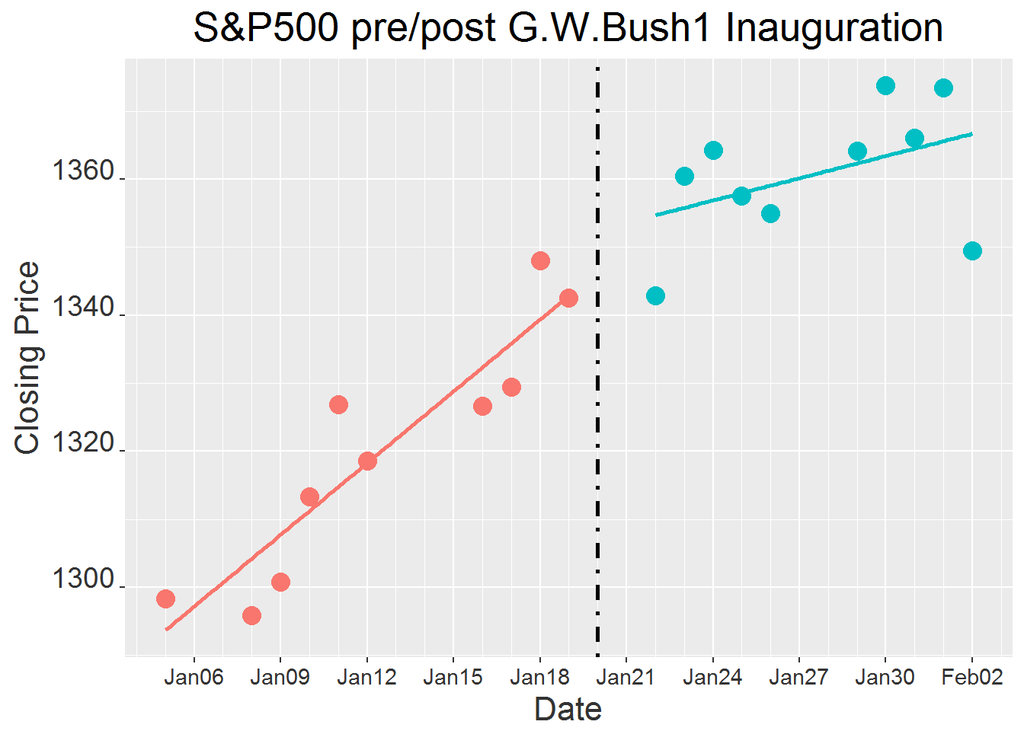

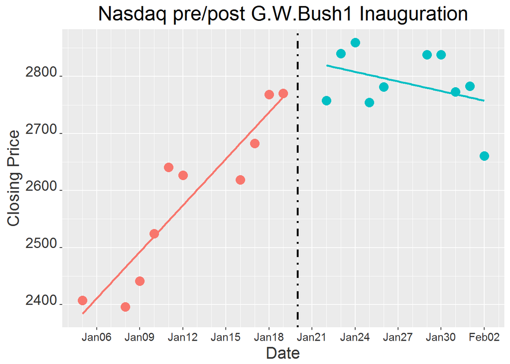

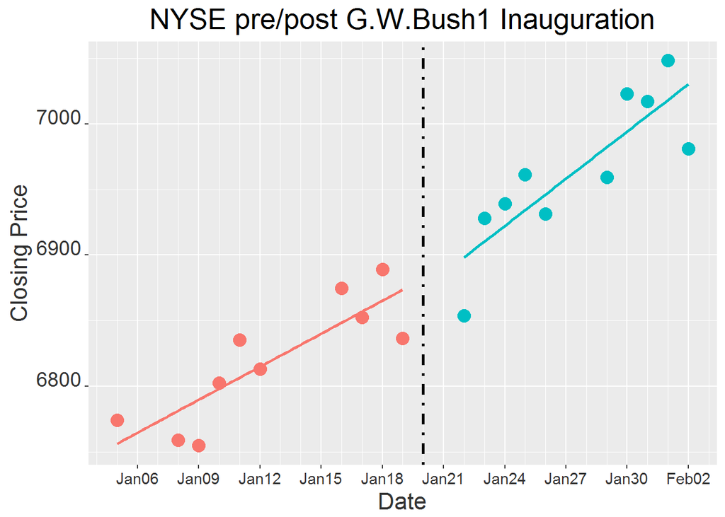

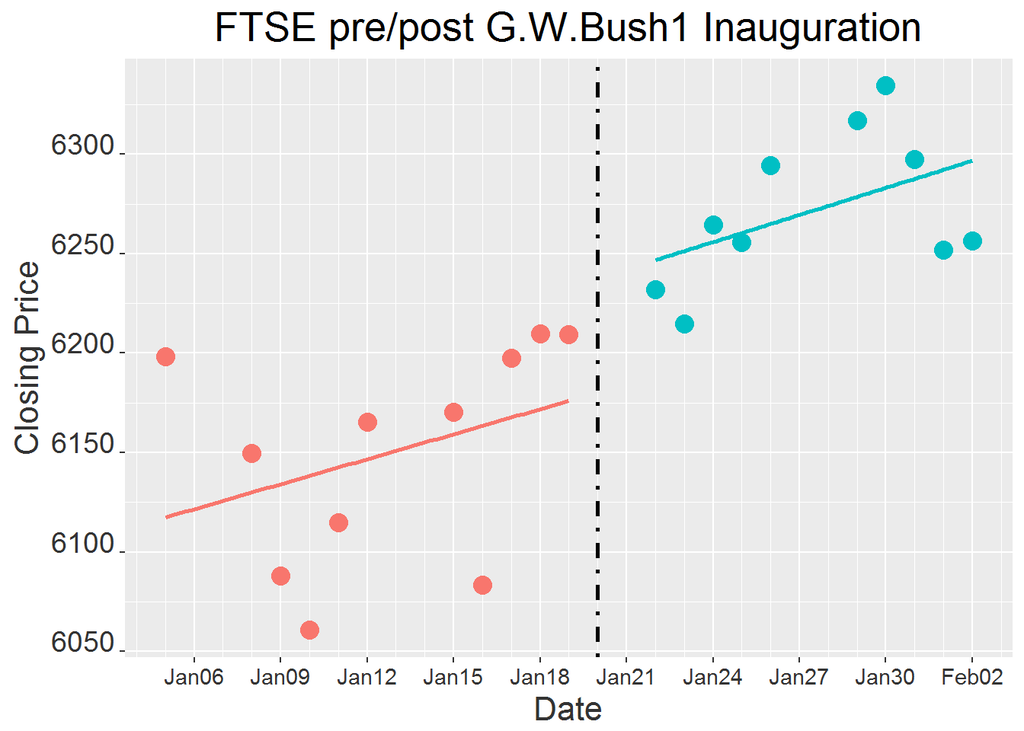

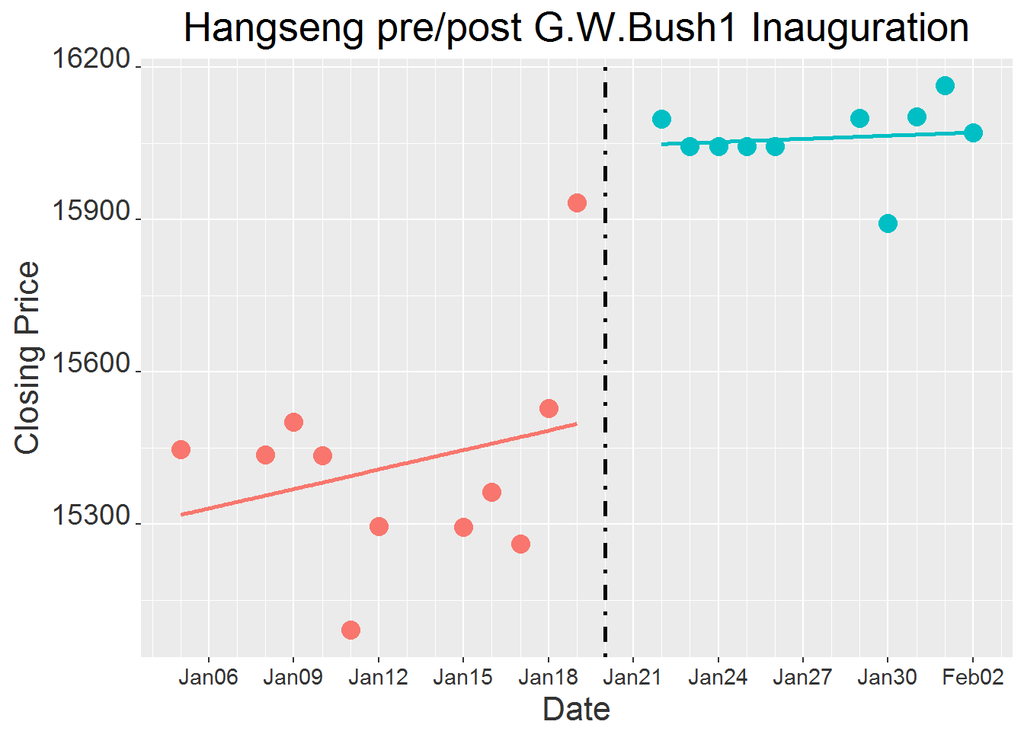

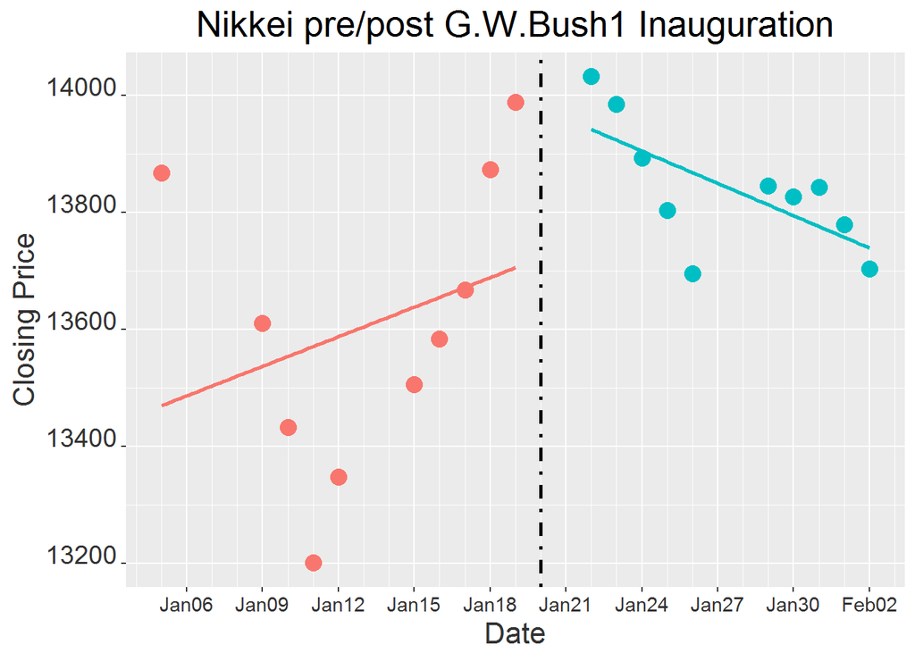

| President | id | Index | GradChange |
| --- | --- | --- | --- |
| GeorgeWBush-1 | 1 | Dow Jones | 56460.49% |
|  | 2 | S&P500 | -68.99% |
|  | 3 | Nasdaq | -120.70% |
|  | 4 | NYSE | 43.14% |
|  | 5 | FTSE | 8.58% |
|  | 6 | Hang Seng | -83.89% |
|  | 7 | Nikkei | -209.30% |

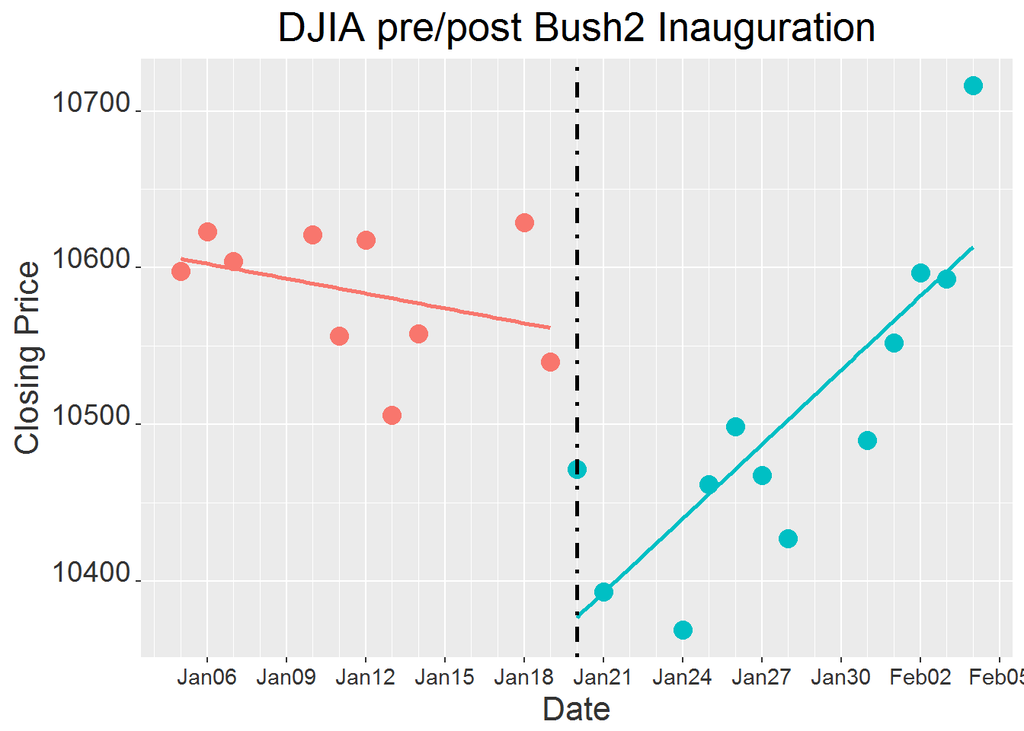

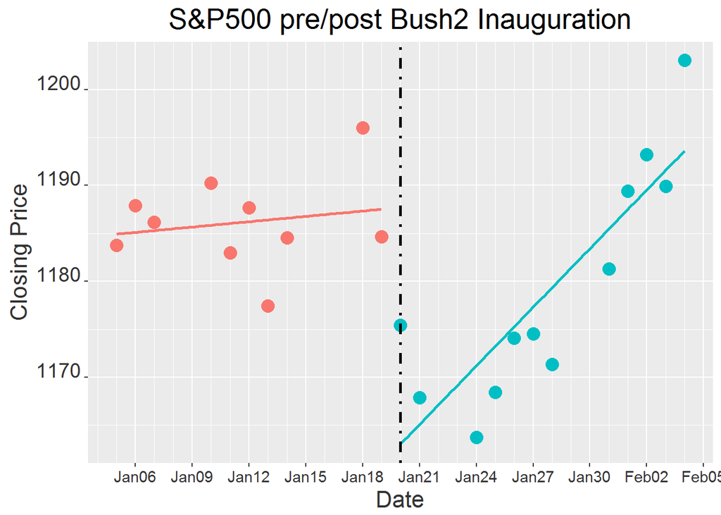

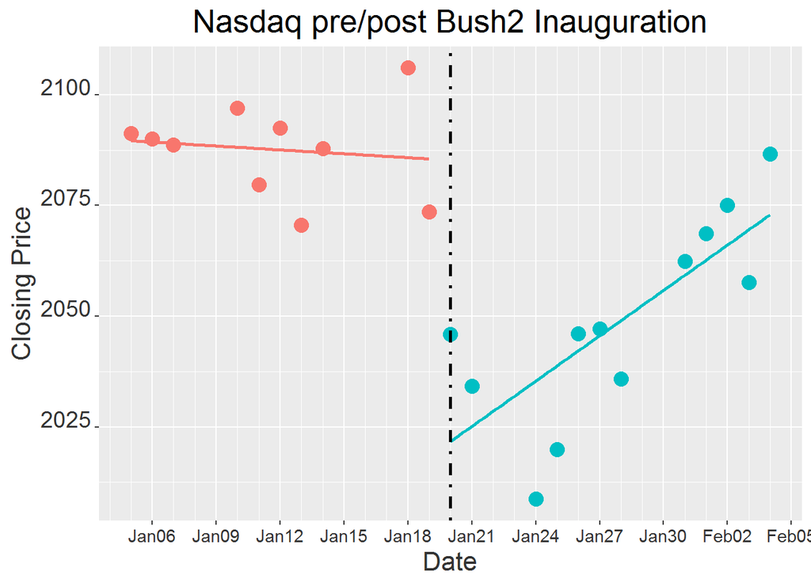

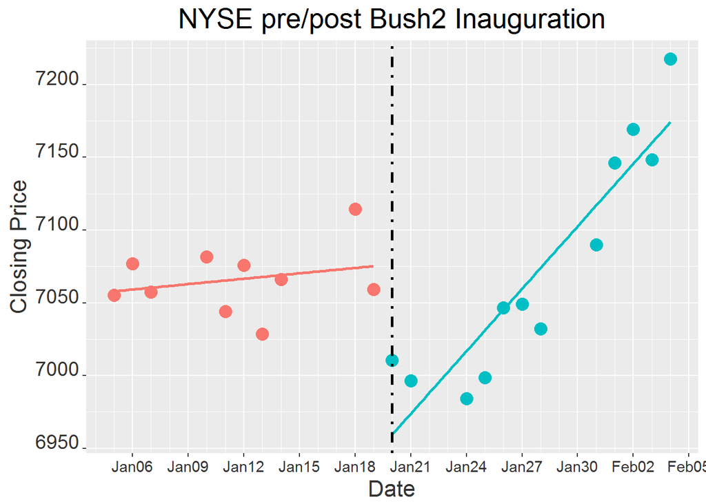

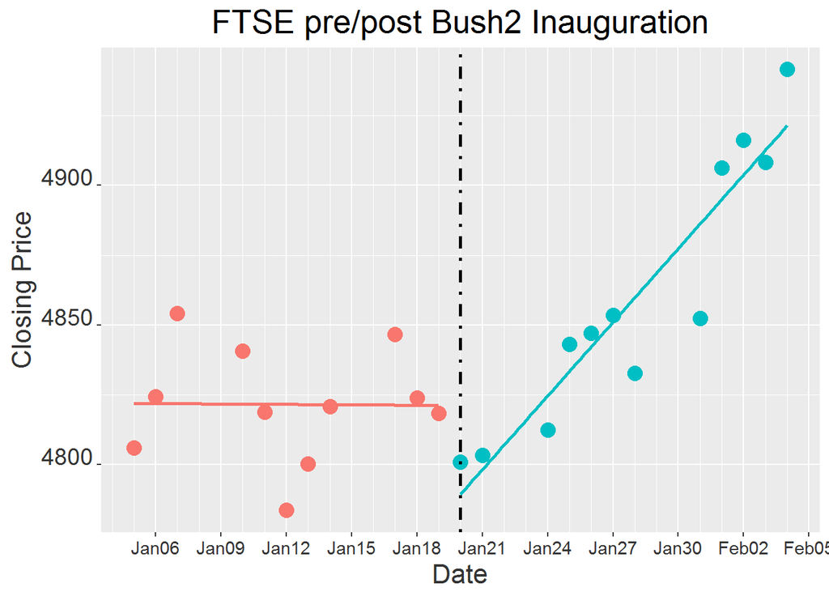

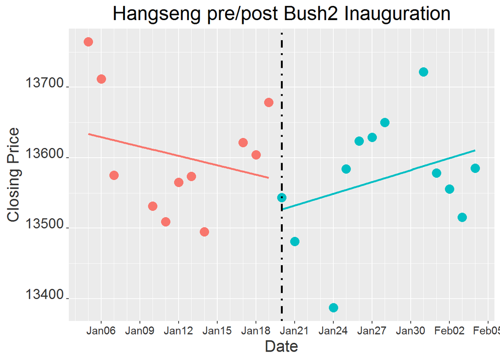

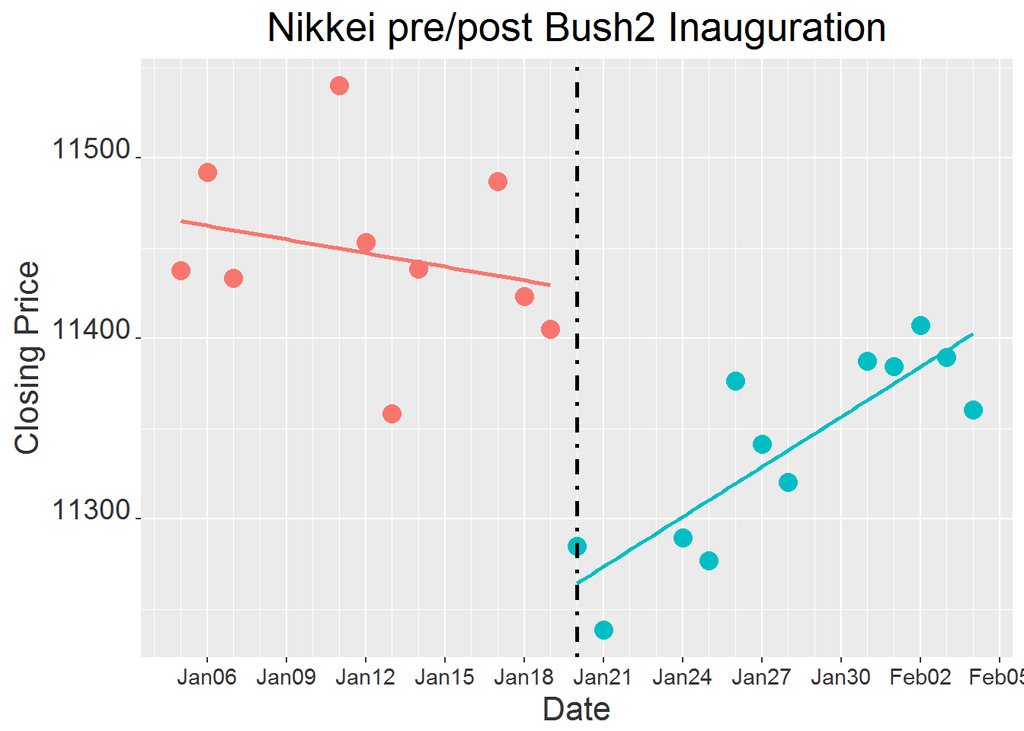

| President | id | Index | GradChange |
| --- | --- | --- | --- |
| GeorgeWBush-2 | 1 | Dow Jones | 599.53% |
|  | 2 | S&P500 | 1001.00% |
|  | 3 | Nasdaq | 1269.32% |
|  | 4 | NYSE | 1059.97% |
|  | 5 | FTSE | 17699.28% |
|  | 6 | Hang Seng | 225.69% |
|  | 7 | Nikkei | 466.03% |

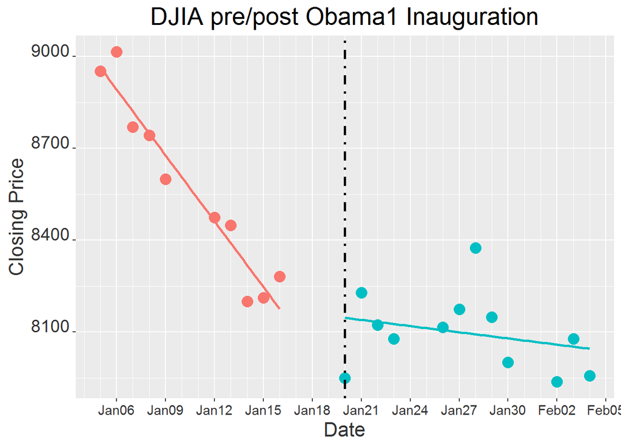

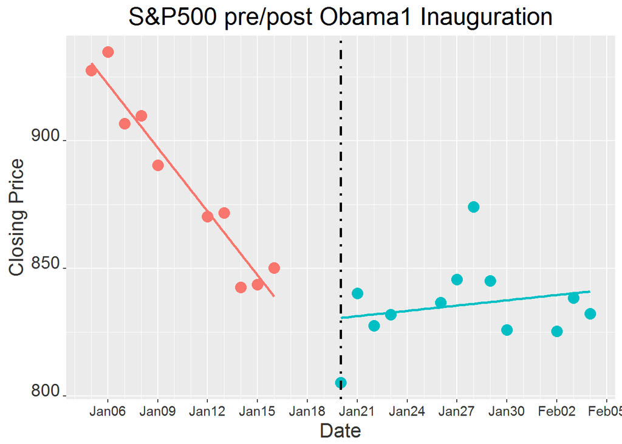

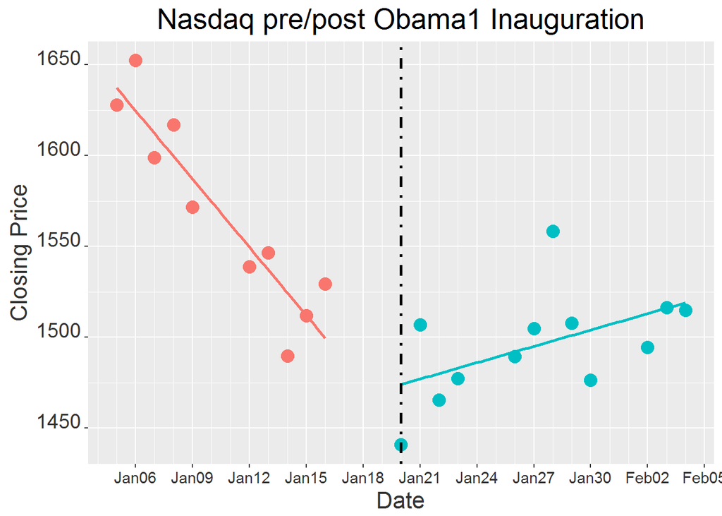

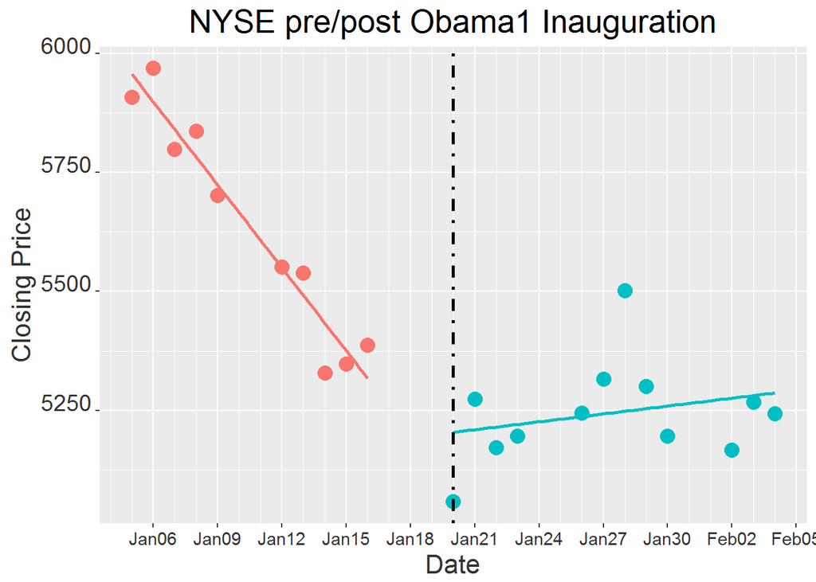

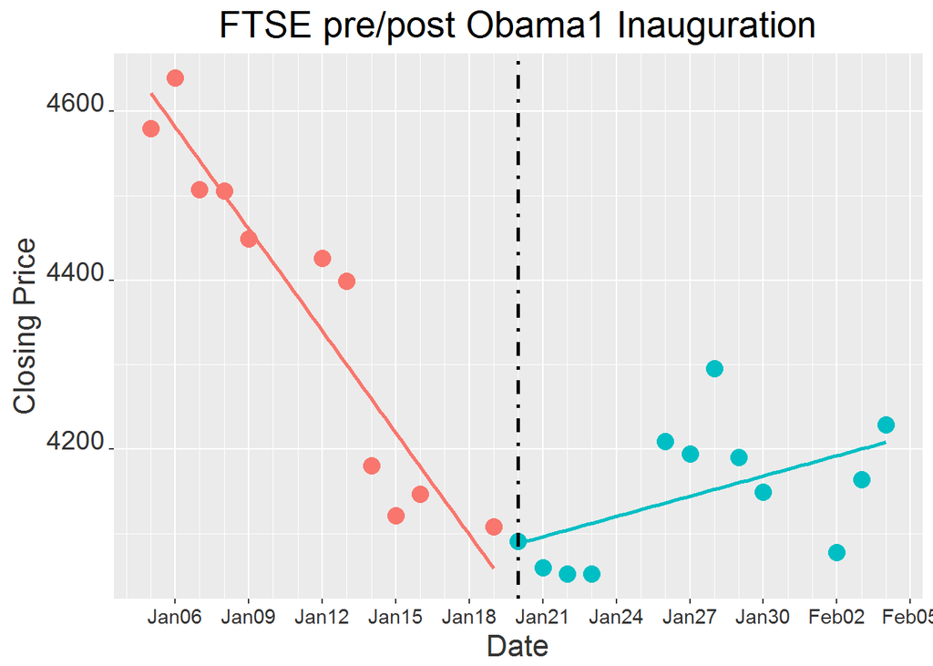

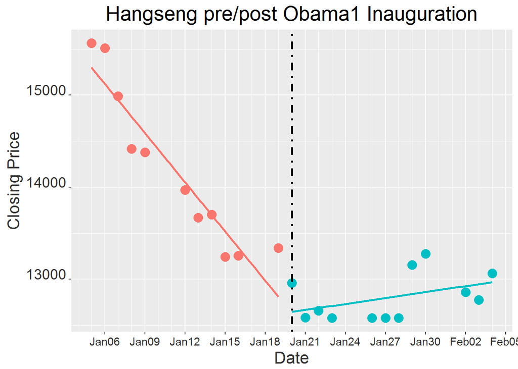

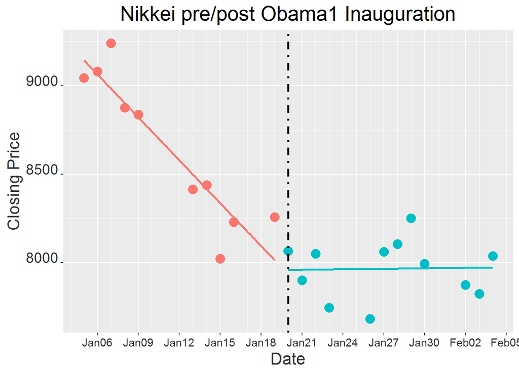

| President | id | Index | GradChange |
| --- | --- | --- | --- |
| BarackObama-1 | 1 | Dow Jones | 90.62% |
|  | 2 | S&P500 | 108.31% |
|  | 3 | Nasdaq | 123.95% |
|  | 4 | NYSE | 109.50% |
|  | 5 | FTSE | 119.85% |
|  | 6 | Hang Seng | 112.11% |
|  | 7 | Nikkei | 101.14% |

### Section III(a): Text Analysis - Diction (Word Clouds)

We now begin our text analysis section. In this section, we will conduct 3 kinds of analysis - the diction used, the sentence structure (in this case, length of sentence), and the emotions behind the words used. Firstly, we start off with a data exploratory section with word clouds of individual presidents in each cluster.

```r
# # ignore this data exploratory section because shiny app doesn't work
#
# shinyApp(
#     ui = fluidPage(
#       fluidRow(style = "padding-bottom: 20px;",
#         column(4, selectInput('speech1', 'Speeches (Mkts Up)',
#                               speeches_up,
#                               selected=speeches_shortened[1])),
#         column(4, selectInput('speech2', 'Speeches (Mkts Down)', speeches_down,
#                               selected=speeches_shortened[3])),
#         column(4, sliderInput('nwords', 'Number of words', 3,
#                                min = 20, max = 200, value=100, step = 20))
#       ),
#       fluidRow(
#         plotOutput('wordclouds', height = "400px")
#       )
#     ),
#
#     server = function(input, output, session) {
#
#       # Combine the selected variables into a new data frame
#       selectedData <- reactive({
#         list(dtm.term1=SpeechCorpus.dtm.up$term[SpeechCorpus.dtm.up$document==as.character(input$speech1)],
#              dtm.count1=SpeechCorpus.dtm.up$count[SpeechCorpus.dtm.up$document==as.character(input$speech1)],
#              dtm.term2=SpeechCorpus.dtm.down$term[SpeechCorpus.dtm.down$document==as.character(input$speech2)],
#              dtm.count2=SpeechCorpus.dtm.down$count[SpeechCorpus.dtm.down$document==as.character(input$speech2)])
#       })
#
#       output$wordclouds <- renderPlot(height = 400, {
#         par(mfrow=c(1,2), mar = c(0, 0, 3, 0))
#         wordcloud(selectedData()$dtm.term1,
#                   selectedData()$dtm.count1,
#               scale=c(4,0.5),
#               max.words=input$nwords,
#               min.freq=1,
#               random.order=F,
#               rot.per=0,
#               use.r.layout=F,
#               random.color=F,
#               colors=brewer.pal(9,"Greens"),
#             main=input$speech1)
#         wordcloud(selectedData()$dtm.term2,
#                   selectedData()$dtm.count2,
#               scale=c(4,0.5),
#               max.words=input$nwords,
#               min.freq=1,
#               random.order=F,
#               rot.per=0,
#               use.r.layout=F,
#               random.color=F,
#               colors=brewer.pal(9,"Reds"),
#             main=input$speech2)
#       })
#     },
#
#     options = list(height = 600)
# )
```

#### Interactive word cloud by Up/Down (by count)

Next, I built an interactive word cloud of the 2 cluster of speeches (marketing lifting in GREEN vs marketing dampening in RED). The first word cloud is based on the count of words in the speeches. Interestingly, we see that there is not much of a difference between both clusters of speeches. Evidently, the types of words used in all inauguration speeches are similar to a large extent.

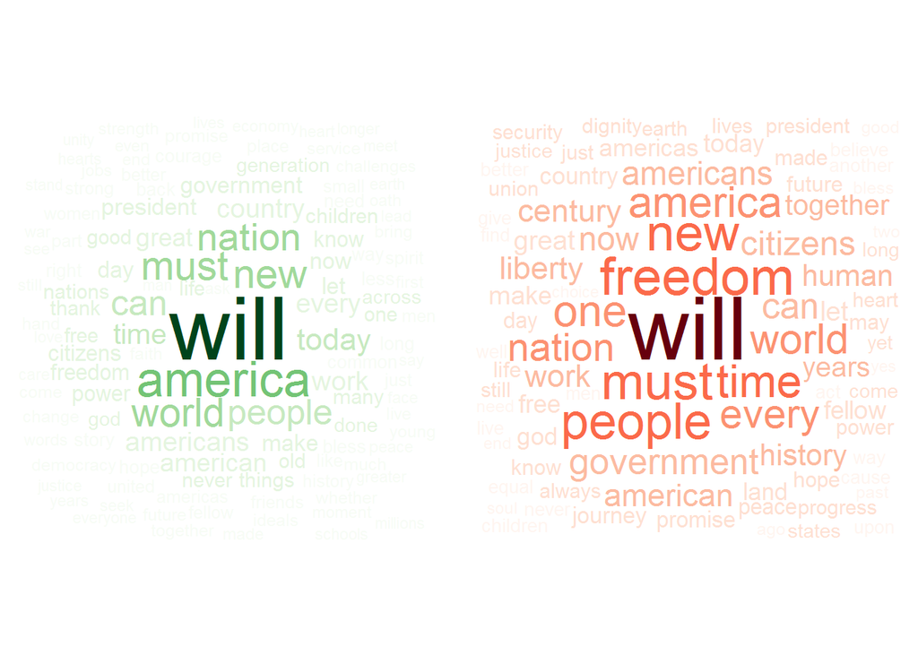

#### Interactive word cloud by Up/Down (by TF-IDF)

The last word clouds built below weighed words using TF-IDF (Market lifting speeches in GREEN and market dampening speeches in RED). This means we are not looking purely at the count of words, but also how rare the word is used in that particular speech. From this word cloud, we see some patterns: the market dampening cluster of speeches tend to have more negative words showing prominently. Another interesting factor is that all “market dampening” speeches are made by second term presidents.

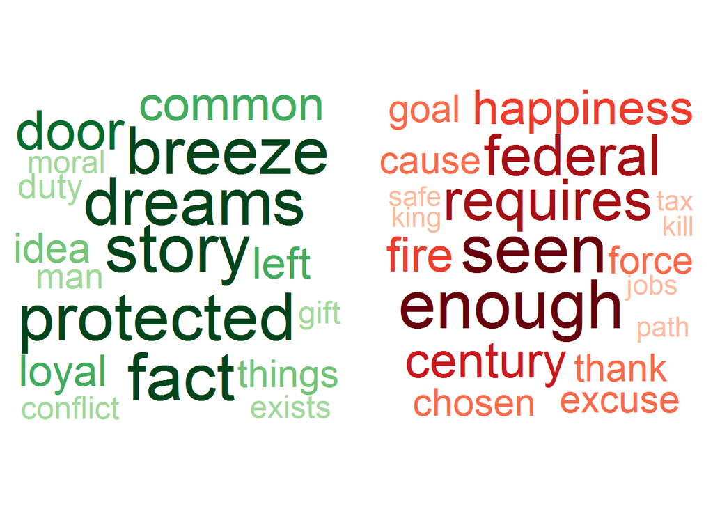

### Section III(b): Text Analysis - Length of Sentence

Following the example in class on analysis by length of sentence, we did a comparison between the clusters of speeches. The results were counterintuitive - speech experts always advocate for shorter sentences for maximum clarity and impact, but in this case, we see that on average the speeches which result in market prices improving have longer sentences. This is worth further research.

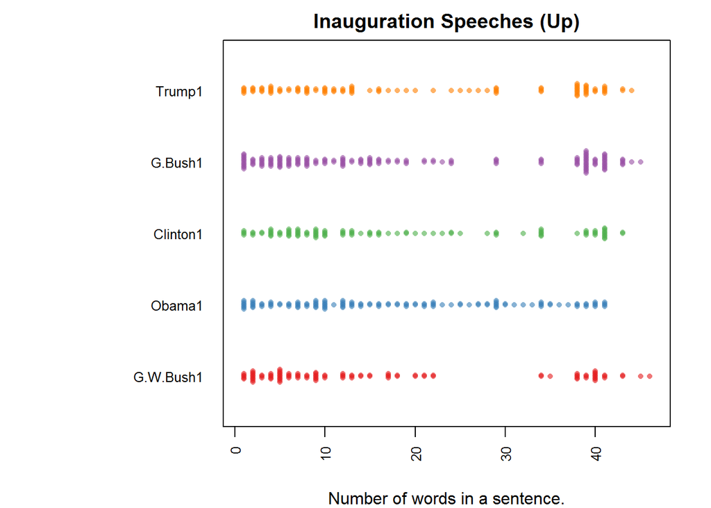

[figure not shown]

```r
# for speeches (up)
sentence.up.list=data.frame()
for(i in 1:nrow(speech_up)){
  sentences=sent_detect(speech_up$fulltext[i],
                        endmarks = c("?", ".", "!", "|",";"))
  if(length(sentences)>0){
    emotions=get_nrc_sentiment(sentences)
    word.count=word_count(sentences)
    # colnames(emotions)=paste0("emo.", colnames(emotions))
    # in case the word counts are zeros?
    emotions=diag(1/(word.count+0.01))%*%as.matrix(emotions)
    sentence.up.list=rbind(sentence.up.list,
                        cbind(speech_up[i,-ncol(speech_up)],
                              sentences=as.character(sentences),
                              word.count,
                              emotions,
                              sent.id=1:length(sentences)
                              )
    )
  }
}

# clean non-existent sentence
sentence.up.list=
  sentence.up.list%>%
  filter(!is.na(word.count) & (word.count != 1))

#######

# for speeches(down)
sentence.down.list=data.frame()
for(i in 1:nrow(speech_down)){
  sentences=sent_detect(speech_down$fulltext[i],
                        endmarks = c("?", ".", "!", "|",";"))
  if(length(sentences)>0){
    emotions=get_nrc_sentiment(sentences)
    word.count=word_count(sentences)
    # colnames(emotions)=paste0("emo.", colnames(emotions))
    # in case the word counts are zeros?
    emotions=diag(1/(word.count+0.01))%*%as.matrix(emotions)
    sentence.down.list=rbind(sentence.down.list,
                        cbind(speech_down[i,-ncol(speech_down)],
                              sentences=as.character(sentences),
                              word.count,
                              emotions,
                              sent.id=1:length(sentences)
                              )
    )
  }
}

# clean non-existent sentence
sentence.down.list=
  sentence.down.list%>%
  filter(!is.na(word.count) & (word.count != 1))

######

# compare length of speech clusters
par(mar=c(4, 11, 2, 2))

#sel.comparison=levels(sentence.list$FileOrdered)
sentence.up.list.length <- sentence.up.list
levels(sentence.up.list.length$V1) <- c("Obama1", "Trump1", "G.Bush1", "G.W.Bush1", "Clinton1")
#sentence.up.list.length$V1= as.factor(sentence.up.list.length$V1)
sentence.up.list.length$word.count = as.numeric(sentence.up.list.length$word.count)


sentence.up.list.length$FileOrdered=reorder(sentence.up.list.length$V1,
                                  sentence.up.list.length$word.count,
                                  mean,
                                  order=T)

beeswarm(word.count~FileOrdered,
         data=sentence.up.list.length,
         horizontal = TRUE,
         pch=16, col=alpha(brewer.pal(9, "Set1"), 0.6),
         cex=0.7, cex.axis=0.8, cex.lab=1,
         spacing=1.2/nlevels(sentence.up.list.length$FileOrdered),
         las=2, xlab="Number of words in a sentence.", ylab= "",
         main="Inauguration Speeches (Up)")
```

### Section III(c): Text Analysis - Sentiment Analysis

Finally, on sentiment analysis. We look at the feelings evoked by the words used by the president. In this case, I clustered all the speeches in each cluster (market dampening vs marketing lifting) and also rearranged the sentences by the “top emotion” evoked. Interestingly, there is a larger proportion of negative and angry feelings in the market lifting speeches. Maybe this corroborates with how President Trump’s speech has such a positive impact on the market.

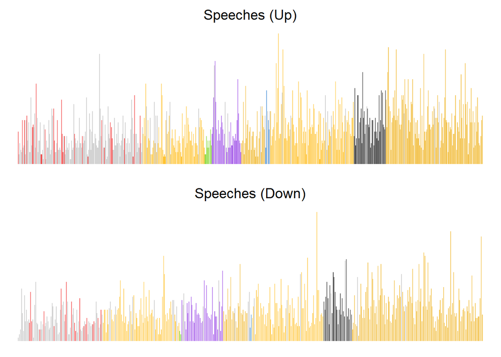

```r
# Speeches (up)
sentence.up.sentiment <- sentence.up.list
colnames(sentence.up.sentiment)[1] <- "Speeches"
sentence.up.sentiment$Speeches <- "Speeches (Up)"
sentence.up.sentiment$topemotionSort=apply(select(sentence.up.sentiment,
                                        anger:positive),
                                 1, which.max)
sentence.up.sentiment <- sentence.up.sentiment[order(sentence.up.sentiment$topemotionSort),]
sentence.up.sentiment$sent.id2 <- sentence.up.sentiment$sent.id
sentence.up.sentiment$sent.id <- 1:nrow(sentence.up.sentiment)


for (i in 3:ncol(sentence.up.sentiment)) {
  sentence.up.sentiment[, i] <- as.numeric(as.character(sentence.up.sentiment[, i]))
}


# Speeches (down)
sentence.down.sentiment <- sentence.down.list
colnames(sentence.down.sentiment)[1] <- "Speeches"
sentence.down.sentiment$Speeches <- "Speeches (down)"
sentence.down.sentiment$topemotionSort=apply(select(sentence.down.sentiment,
                                        anger:positive),
                                 1, which.max)
sentence.down.sentiment <- sentence.down.sentiment[order(sentence.down.sentiment$topemotionSort),]
sentence.down.sentiment$sent.id2 <- sentence.down.sentiment$sent.id
sentence.down.sentiment$sent.id <- 1:nrow(sentence.down.sentiment)


for (i in 3:ncol(sentence.down.sentiment)) {
  sentence.down.sentiment[, i] <- as.numeric(as.character(sentence.down.sentiment[, i]))
}

par(mfrow=c(2,1), mar=c(1,0,2,0), bty="n", xaxt="n", yaxt="n", font.main=1)
f.plotsent.len(In.list=sentence.up.sentiment, NameTerm="Speeches (Up)")
f.plotsent.len(In.list=sentence.down.sentiment, NameTerm="Speeches (Down)")
```